# BIPPS Simulation Example: Varying number of latent fators

### Tail ESS

Tail ESS focuses specifically on the sampling efficiency in the distribution tails, which is crucial for accurate estimation of quantiles and intervals. Tail ESS is often lower than bulk ESS because extreme values are encountered less frequently during sampling. This diagnostic is particularly important when inference about extreme probabilities or rare events is needed.

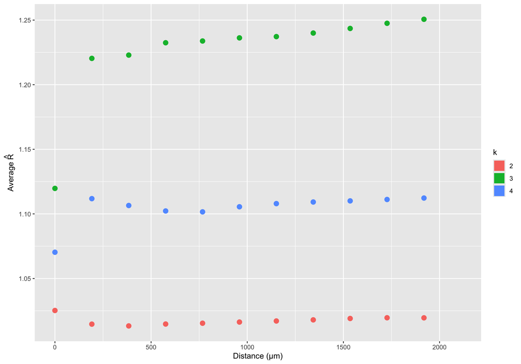

```r
xl_e %>%
  mutate(trial_k=factor(trial_k)) %>%
  mutate(hs = hs*max(x_max,y_max)) %>%
  group_by(hs,actual_k,trial_k) %>%
  summarise(mean_rhat=mean(rhat,na.rm = T)) %>%
  ggplot(aes(x=hs,y=mean_rhat,color=trial_k,fill=trial_k)) +
  stat_halfeye() +
  labs(y=TeX("Average $\\hat{R}$"),x="Distance (\u03bcm)",color="k",fill="k")
```

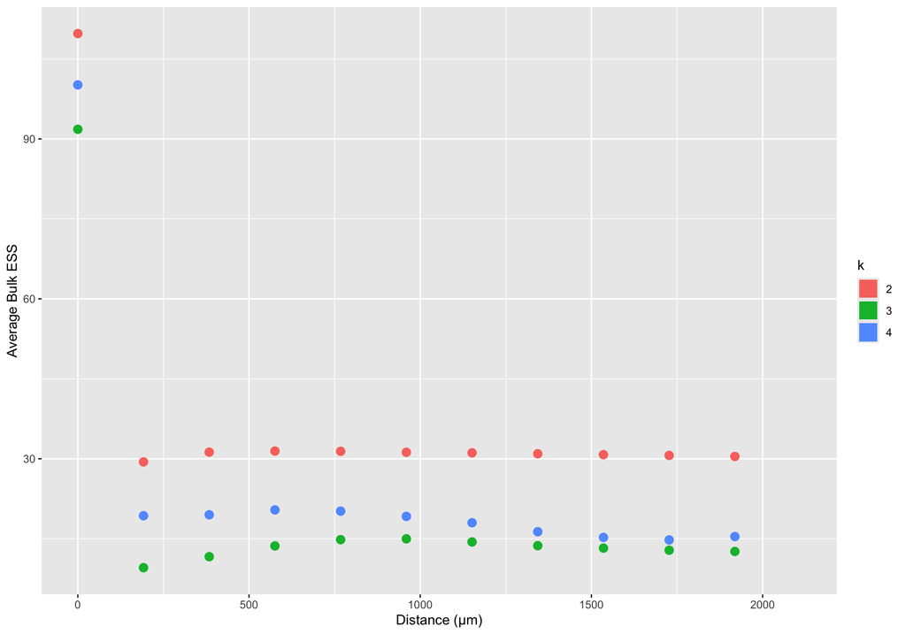

```r
xl_e %>%
  mutate(trial_k=factor(trial_k)) %>%
  mutate(hs = hs*max(x_max,y_max)) %>%
  group_by(hs,actual_k,trial_k) %>%
  summarise(mean_ess=mean(ess_bulk,na.rm = T)) %>%
  ggplot(aes(x=hs,y=mean_ess,color=trial_k,fill=trial_k)) +
  stat_halfeye() +
  labs(y="Average Bulk ESS",x="Distance (\u03bcm)",color="k",fill="k")
```

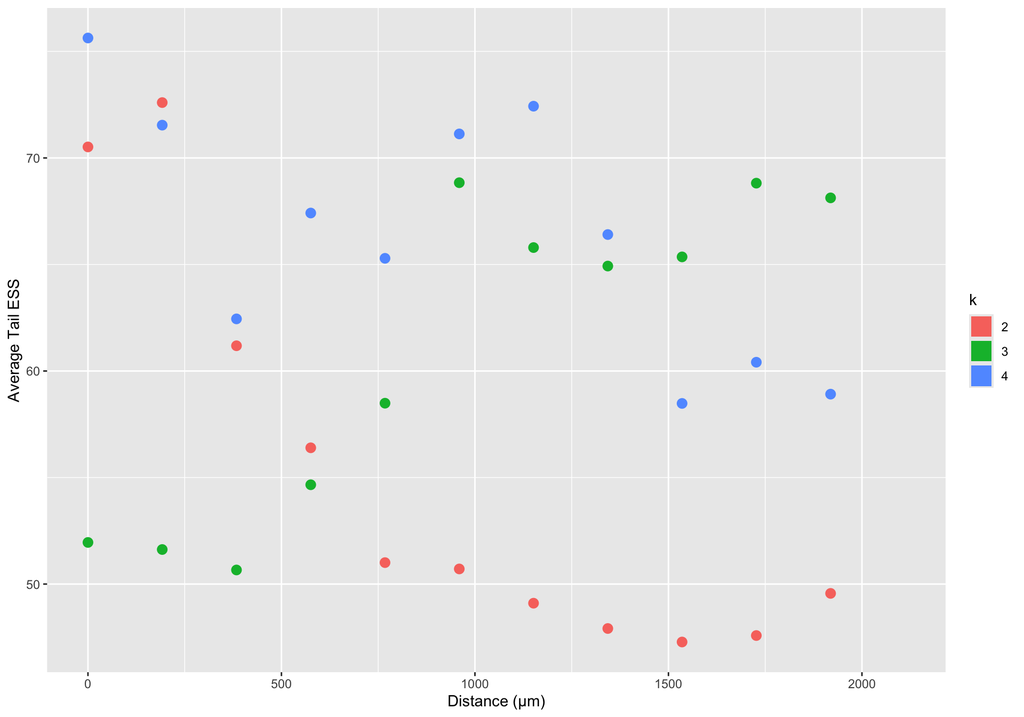

```r
xl_e %>%
  mutate(trial_k=factor(trial_k)) %>%
  mutate(hs = hs*max(x_max,y_max)) %>%
  group_by(hs,actual_k,trial_k) %>%
  summarise(mean_ess=mean(ess_tail,na.rm = T)) %>%
  ggplot(aes(x=hs,y=mean_ess,color=trial_k,fill=trial_k)) +
  stat_halfeye() +
  labs(y="Average Tail ESS",x="Distance (\u03bcm)",color="k",fill="k")
```

## MCMC Trace Plots

Trace plots are essential for assessing MCMC convergence. We want to see that the chains have mixed well and are exploring the parameter space efficiently:

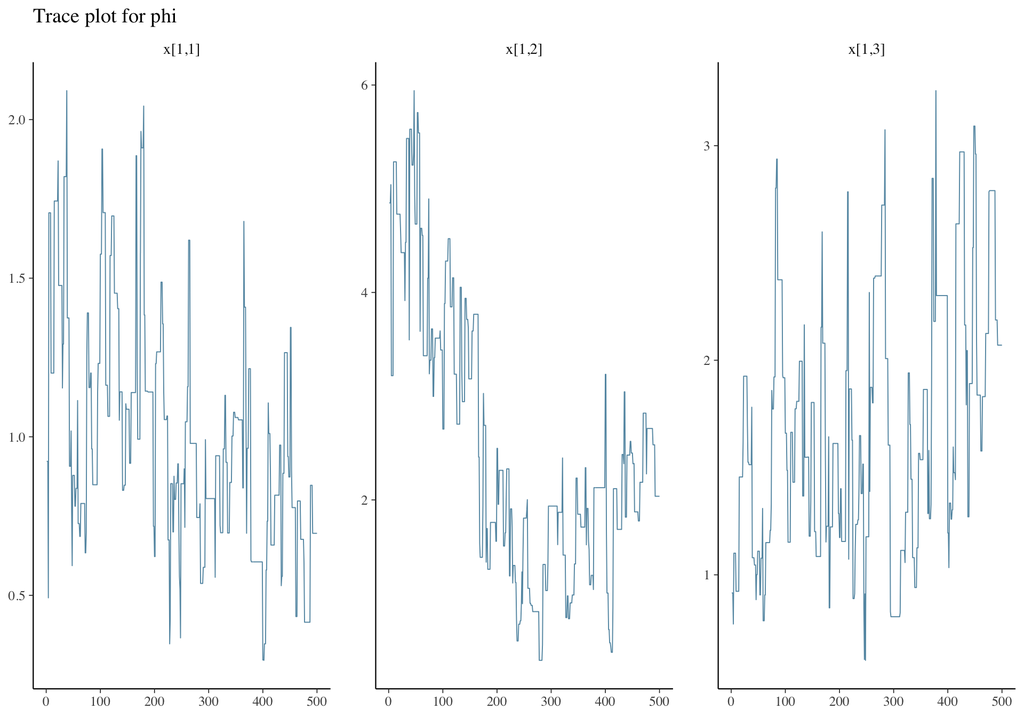

```r
# Get trace plots for spatial decay parameters
if (actual_k %in% trial_ks) {
  # Extract theta (containing phi parameters)
  theta <- get_rvars(results[as.character(actual_k)], "theta", thin = n_thin)

  # Plot trace for the first row (phi parameters)
  mcmc_trace(as_draws_df(theta[1, ])) + ggtitle("Trace plot for phi")
}
```

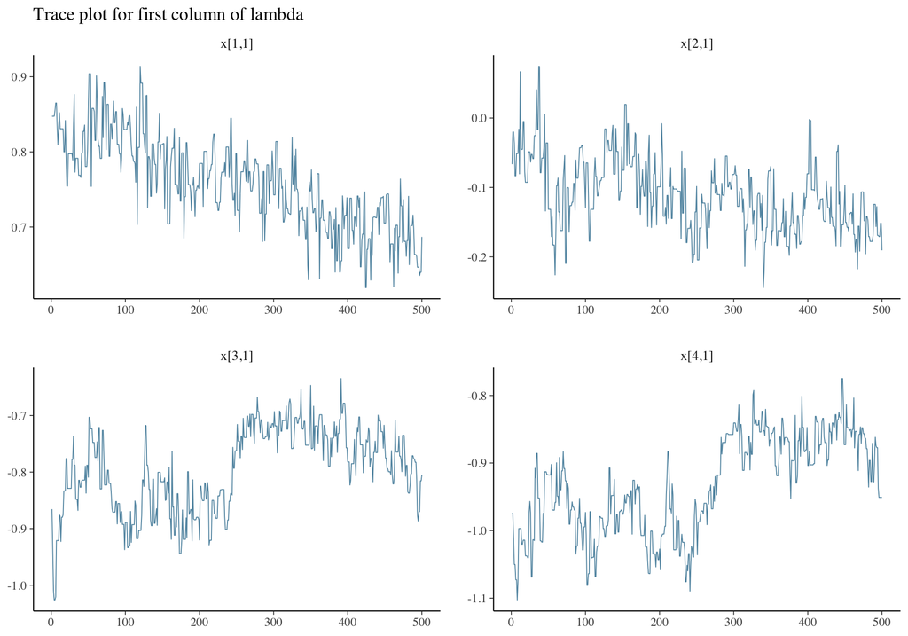

```r
# Trace plots for factor loadings (Lambda)
lambda <- get_rvars(results[as.character(actual_k)], "lambda", thin = n_thin)
mcmc_trace(as_draws_df(lambda[, 1])) + ggtitle("Trace plot for first column of lambda")  # First column of lambda
```

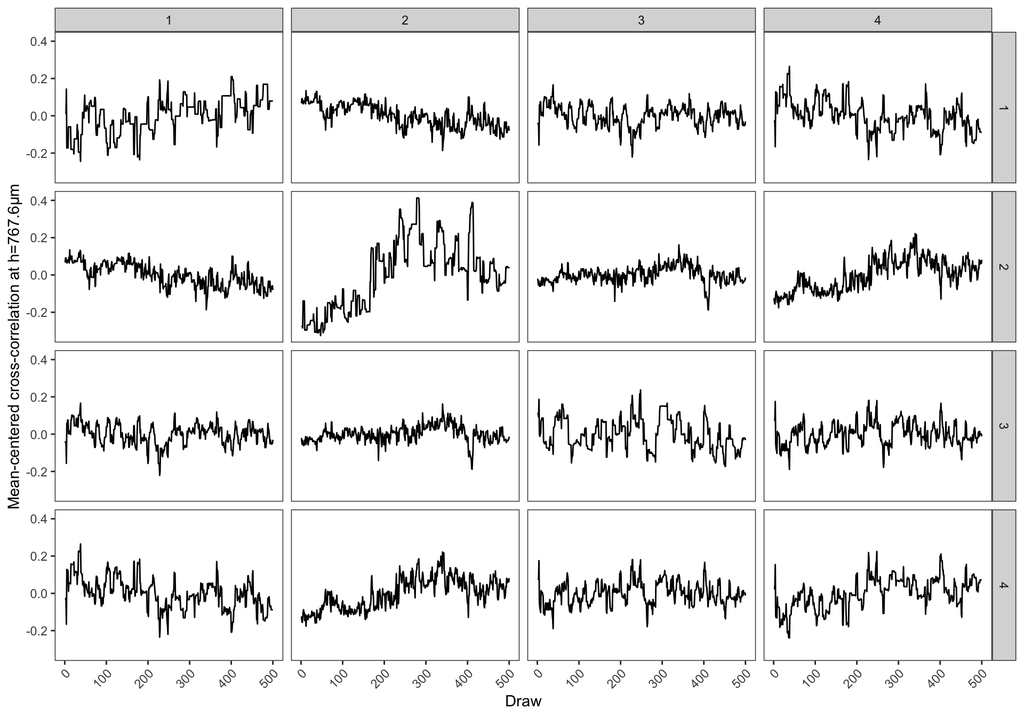

```r
# Trace plots for cross-correlations at a specific distance
h_ix <- 5  # Index for distance bin
hs <- seq(0, 1, 0.1)  # Distance bins
xl <- cross_list(results[as.character(actual_k)], hs, thin = n_thin)

# Create and plot trace data
trace_df <- as_draws_df(xl[[h_ix]]) %>%
  pivot_longer(-c(".chain", ".iteration", ".draw"), names_to = "variable") %>%
  separate(variable, into = c("type1", "type2"), sep = ",") %>%
  mutate(
    type1 = sub("^x\\[", "", type1),
    type2 = sub("\\]", "", type2)
  )

# Center each trace around its mean to better visualize mixing
ggplot(
  trace_df %>%
    mutate(.chain = factor(.chain)) %>%
    mutate(type1 = factor(type1, levels = 1:q)) %>%
    mutate(type2 = factor(type2, levels = 1:q)) %>%
    group_by(type1, type2) %>%
    mutate(value = value - mean(value)) %>%
    ungroup(),
  aes(.iteration, value)
) +
  geom_line() +
  facet_grid(
    type1 ~ type2,
    labeller = label_wrap_gen(width = 8)
  ) +
  theme_bw() +
  theme(
    panel.grid.major = element_blank(),
    panel.grid.minor = element_blank(),
    axis.text.x = element_text(angle = 45, hjust = 1, vjust = 1)
  ) +
  labs(
    x = "Draw",
    y = paste0("Mean-centered cross-correlation at h=", hs[h_ix] * max(x_max, y_max), "μm")
  )
```

Here we can see that our MCMC chains definitely don’t seem to have converged, which makes sense, since we only had 500 burn-in samples! Running for longer should make convergence look much better.

# Analyzing Spatial Cross-Correlation

One of the key features of BIPPS is its ability to model the spatial cross-correlation between different types (or components) of the response. Here, we’ll analyze how well our models capture these spatial relationships.

## Spatial Cross-Correlation Analysis

We’ll compute and visualize the spatial cross-correlation functions for different pairs of response types:

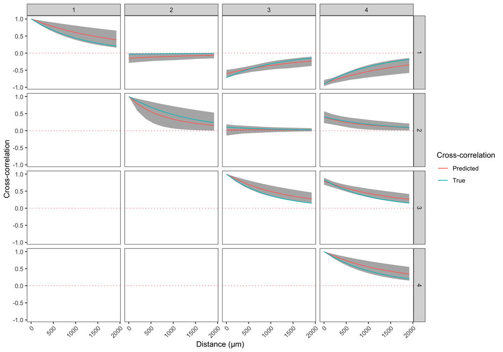

```r
# Plot cross-correlations
xl_e %>%
  filter(trial_k == actual_k) %>%
  mutate(hs = hs * max(x_max, y_max)) %>%
  rename(Predicted = mu, True = mu_actual) %>%
  pivot_longer(c(Predicted, True)) %>%
  ggplot() +
  geom_ribbon(aes(hs, ymin = lb, ymax = ub), fill = "grey70") +
  geom_line(aes(hs, value, color = name)) +
  geom_hline(yintercept = 0, color = "red", alpha = 0.5, linetype = "dotted") +
  theme_bw() +
  theme(
    panel.grid.major = element_blank(),
    panel.grid.minor = element_blank(),
    axis.text.x = element_text(angle = 45, hjust = 1, vjust = 1)
  ) +
  facet_grid(t1 ~ t2) +
  labs(
    x = "Distance (μm)",
    y = "Cross-correlation",
    color = "Cross-correlation"
  )
```

The plot above shows the spatial cross-correlation functions for each pair of response types. For each pair:

- The blue line represents the true cross-correlation from our model
- The red line represents the estimated cross-correlation function
- The grey ribbon shows the 95% credible interval for our estimate
- The x-axis represents the spatial distance in micrometers

When our model is performing well, the estimated cross-correlation should closely follow the true cross-correlation, and the credible intervals should include the true values.

## Comparing Intensity Surfaces

We can also compare the estimated intensity surfaces with the true ones and the observed counts:

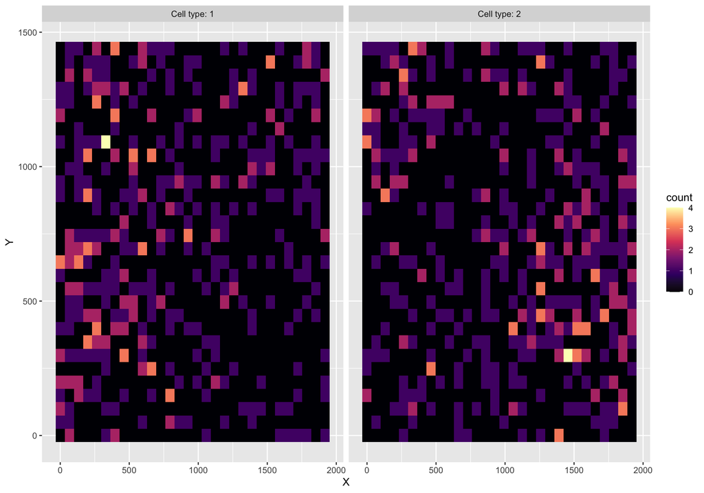

```r
# Plot observed counts, true intensity, and predicted intensity
# Select a subset of images and types for visualization
image_idx <- 1
types_idx <- 1:2

# Extract observed counts
y_list_subset <- lapply(y_list[image_idx], \(yy) {
  yy <- yy[, types_idx]
  colnames(yy) <- paste0("Cell type: ", types_idx)
  yy
})

# Extract true intensity surfaces
WW_subset <- lapply(WW[image_idx], \(ww) {
  ww <- ww[, types_idx]
  colnames(ww) <- paste0("Cell type: ", types_idx)
  ww
})

# Create plots
py <- plot_y_list(y_list_subset, coords * max(x_max, y_max))
pW <- plot_y_list(WW_subset, coords * max(x_max, y_max))

# Get predicted intensity
# Extract posterior means for V (latent factors) and Lambda (loadings)
vhat <- results[[as.character(actual_k)]]$v_mcmc
vhat <- lapply(vhat,\(v) v[1:(nx*ny),])
arr <- simplify2array(vhat)
arr <- aperm(arr,perm=c(3,1,2))
vhat <- posterior::rvar(arr)

beta <- results[[as.character(actual_k)]]$beta_mcmc
arr <- beta
arr <- arr[,,seq(1,dim(arr)[3],by=n_thin),drop=FALSE]
arr <- aperm(arr,perm=c(3,1,2))
beta <- posterior::rvar(arr)

# Calculate predicted intensity surface
lp_e <- E(vhat %*% t(lambda) + matrix(1,nrow=nx*ny,ncol=p) %*% beta)
colnames(lp_e) <- paste0("Cell type: ", 1:q)

# Plot predicted intensity
p3 <- dplyr::bind_cols(lp_e[,types_idx],coords * max(x_max,y_max)) %>%
  tidyr::pivot_longer(-c(x,y),names_to = "type",values_to = "count") %>%
  ggplot2::ggplot(ggplot2::aes(x,y,fill=count)) +
  ggplot2::geom_tile() +
  ggplot2::facet_wrap(~type,ncol=2) +
  ggplot2::scale_fill_viridis_c(option="magma") +
  theme(axis.text = element_blank(),
        axis.title.y=element_blank()) +
  guides(fill="none")


py[[1]]
```

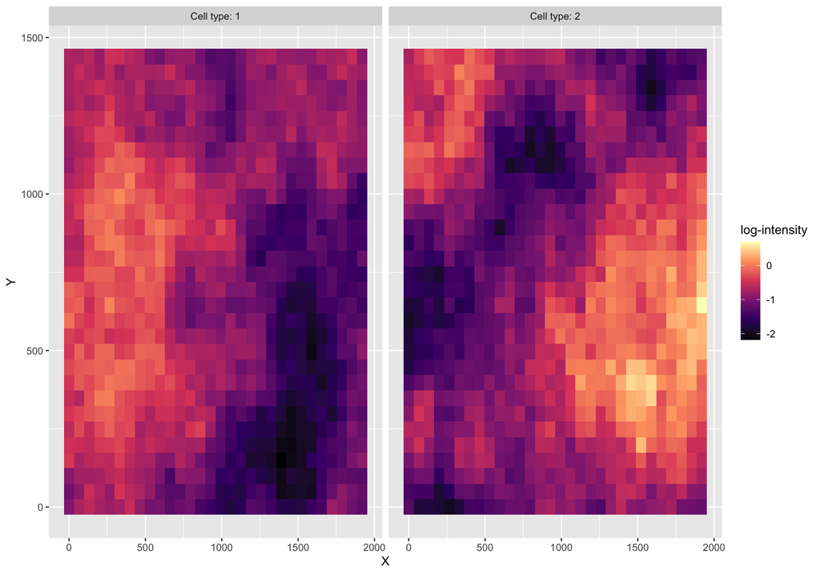

```r
pW[[1]] + labs(fill="log-intensity")
```

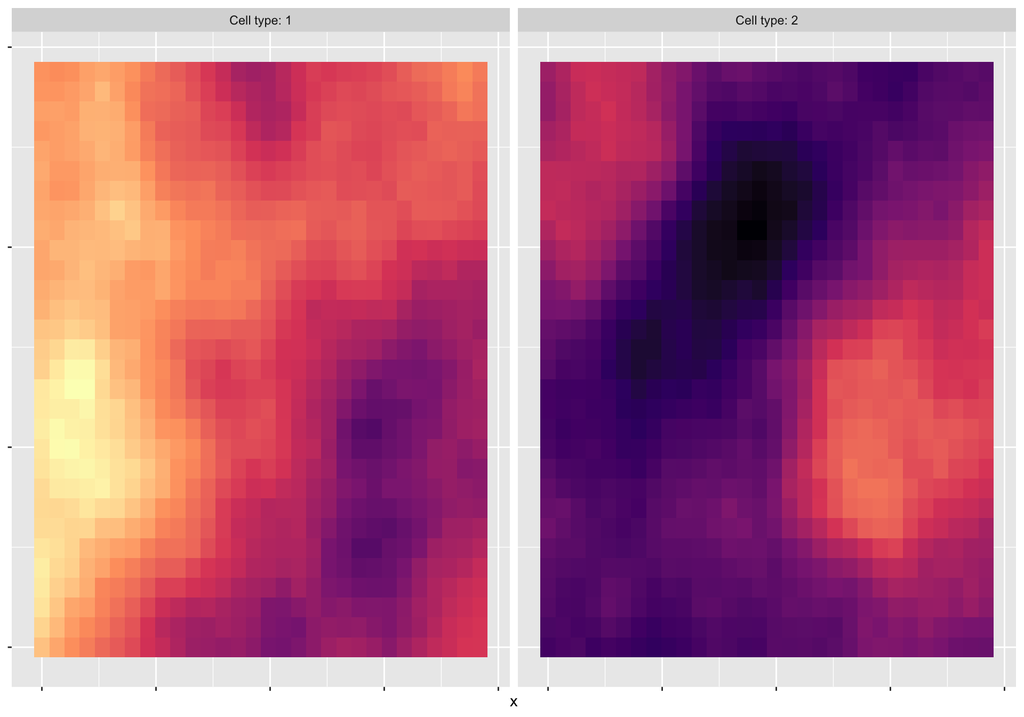

```r
p3
```

The figure shows:

- Plot 1: Observed count data for selected cell types
- Plot 2: True underlying intensity that generated the counts
- Plot 3: Model-predicted intensity surfaces

When the model fits well, the predicted intensity surfaces should closely match the true intensity surfaces, despite the randomness in the observed counts.

# Conclusion

In this example, we demonstrated:

1. How to set up and run BIPPS simulations with varying numbers of latent factors
2. The process of generating synthetic spatial point process data
3. How to fit BIPPS models with different specifications
4. Methods for comparing model performance and evaluating results

The simulation framework allows us to test how well BIPPS can recover the true underlying structure of spatial point process data. By comparing models with different numbers of latent factors, we can develop insights into model selection and specification.

## Next Steps

Potential extensions of this analysis could include:

1. Varying other parameters like the spatial decay range
2. Testing with different point process families (e.g., Negative Binomial)
3. Adding covariates to the model
4. Exploring different spatial correlation structures